# Reproducible Research: Peer Assessment 1

This report demonstrates some of the analysis of daily activities that is possible using personal activity monitoring devices (like a Fitbit, Nike Fuelband, or Jawbone Up) and a powerful data analysis language like R. Specifically, this report will illustrate the R code necessary to input, process, visualize, and analyze the activity data collected by an anonymous individual in the months of October and November 2012.

## Loading and preprocessing the data

The data for this analysis has been archived as a zip file, so the first step will be to extract the files from the archive and save them in a data directory, but only if the files haven’t been extracted previously. The following R code will check to see if the data directory has already been created and will unzip the archive if it hasn’t.

```r
if(!file.exists("./data")) {
    unzip("activity.zip", exdir = "./data", unzip = "internal")
}
```

Now that the data has been extracted from the archive, the contents of the data directory can be listed.

```r
list.files("./data")
```

```
## [1] "activity.csv"
```

The data file contains a single comma-separated values (CSV) file, so the next step is to read the file contents into an R object called activityData so it can be analyzed.

```r
activityData <- read.csv("./data/activity.csv")
```

Viewing the first 15 rows of the R object and a summary will show what the variable names are, what the data values look like, and what their ranges are.

```r
head(activityData, 15)
```

```
##    steps       date interval
## 1     NA 2012-10-01        0
## 2     NA 2012-10-01        5
## 3     NA 2012-10-01       10
## 4     NA 2012-10-01       15
## 5     NA 2012-10-01       20
## 6     NA 2012-10-01       25
## 7     NA 2012-10-01       30
## 8     NA 2012-10-01       35
## 9     NA 2012-10-01       40
## 10    NA 2012-10-01       45
## 11    NA 2012-10-01       50
## 12    NA 2012-10-01       55
## 13    NA 2012-10-01      100
## 14    NA 2012-10-01      105
## 15    NA 2012-10-01      110
```

```r
summary(activityData)
```

```
##      steps               date          interval
##  Min.   :  0.0   2012-10-01:  288   Min.   :   0
##  1st Qu.:  0.0   2012-10-02:  288   1st Qu.: 589
##  Median :  0.0   2012-10-03:  288   Median :1178
##  Mean   : 37.4   2012-10-04:  288   Mean   :1178
##  3rd Qu.: 12.0   2012-10-05:  288   3rd Qu.:1766
##  Max.   :806.0   2012-10-06:  288   Max.   :2355
##  NA's   :2304    (Other)   :15840
```

It appears that the data file contains a *steps* variable, which may not be available, the *date* of the observation in Year-Month-Day format, and an *interval* between observations of five minutes with the hundreds positions indicating the hours (e.g., 105 indicates the interval at 1:05). The summary also shows that there appear to be 288 observations per day and the maximum range of the *interval* is from 0 to 2355 (24 hours of observations).

It may be easier for later analysis to convert the *date* and *interval* variables into a standard R date and time variable. The following R code uses the **formatC** function to convert the varying length *interval* values to four digits with leading zeros and the **strptime** function to convert the *date* and *interval* values into POSIX data-time format and adds them as a new column in *activityData*.

```r
activityData$datetime <- strptime(paste(activityData$date,
                                        formatC(activityData$interval,
                                                width = 4,
                                                format = "d",
                                                flag = "0")),
                                        format = "%Y-%m-%d %H%M")
head(activityData)
```

```
##   steps       date interval            datetime
## 1    NA 2012-10-01        0 2012-10-01 00:00:00
## 2    NA 2012-10-01        5 2012-10-01 00:05:00
## 3    NA 2012-10-01       10 2012-10-01 00:10:00
## 4    NA 2012-10-01       15 2012-10-01 00:15:00
## 5    NA 2012-10-01       20 2012-10-01 00:20:00
## 6    NA 2012-10-01       25 2012-10-01 00:25:00
```

## What is mean total number of steps taken per day?

The total number of steps per day can be visualized as a histogram using the following code.

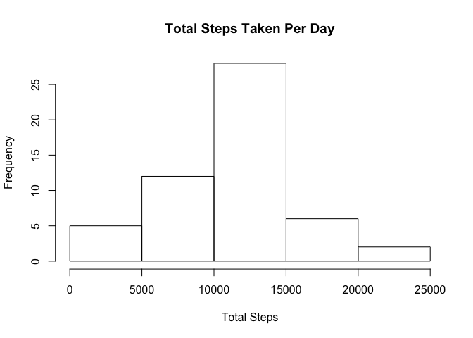

```r
stepsPerDay <- aggregate(activityData$steps ~ activityData$date,
                         activityData,
                         sum)
hist(stepsPerDay[ , 2],
     main = "Total Steps Taken Per Day",
     xlab = "Total Steps")
```

The mean of the total number of steps per day can be calculated as follows.

```r
mean(stepsPerDay[ , 2])
```

```
## [1] 10766
```

Likewise, the median can also be determined.

```r
median(stepsPerDay[ , 2])
```

```
## [1] 10765
```

## What is the average daily activity pattern?

The following R code calculates and plots the average number of steps per time interval.

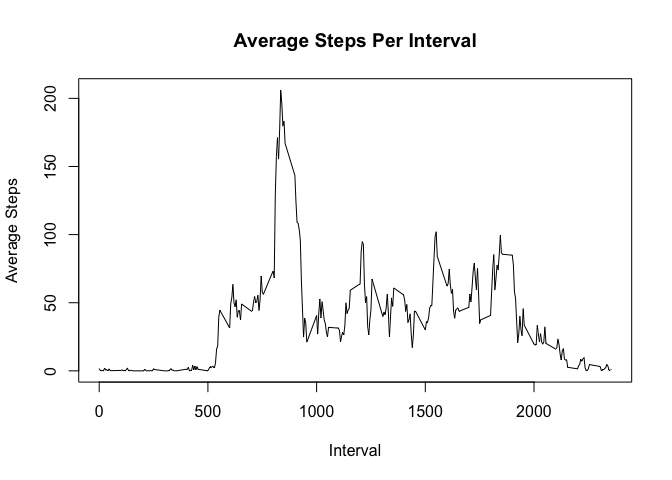

```r
stepsPerInterval <- aggregate(activityData$steps ~ activityData$interval,
                              activityData,
                              ave)
plot(stepsPerInterval[, 1], stepsPerInterval[ , 2][ , 1], type = "l",
     main = "Average Steps Per Interval",
     xlab = "Interval", ylab = "Average Steps")
```

```r
stepsPerInterval[max(stepsPerInterval[ , 2][ , 1]), 1]
```

```
## [1] 1705
```

## Imputing missing values

The following R code shows how many missing (“NA”) values are in the data set for the *steps* data.

```r
sum(is.na(activityData$steps) == TRUE)
```

```
## [1] 2304
```

There are a number of possible strategies for replacing the missing values in the data set. In the last section the average number of steps per time interval over all dates was calculated. The average could be used to replace the “NA” value in the missing time intervals. In the section prior to the last one, the daily average steps were calculated. The daily average could also be substituted for the missing values. However, in this dataset, the activity of the wearer of the device is being tracked. Assuming this is for the purpose of improving fitness, adding average values could very well overestimate the activity of the wearer, so I have decided to just replace all of the “NA” values with zeroes. This code creates a new data frame with all numeric values (no “NAs”).

```r
numericActivityData <- activityData
numericActivityData[is.na(numericActivityData)] <- 0
head(numericActivityData)
```

```
##   steps       date interval            datetime
## 1     0 2012-10-01        0 2012-10-01 00:00:00
## 2     0 2012-10-01        5 2012-10-01 00:05:00
## 3     0 2012-10-01       10 2012-10-01 00:10:00
## 4     0 2012-10-01       15 2012-10-01 00:15:00
## 5     0 2012-10-01       20 2012-10-01 00:20:00
## 6     0 2012-10-01       25 2012-10-01 00:25:00
```

Comparing the contents of this data set with the following listing of the first six rows of the original data set demonstrates that the NAs have been replaced with zeroes.

```r
head(activityData)
```

```
##   steps       date interval            datetime
## 1    NA 2012-10-01        0 2012-10-01 00:00:00
## 2    NA 2012-10-01        5 2012-10-01 00:05:00
## 3    NA 2012-10-01       10 2012-10-01 00:10:00
## 4    NA 2012-10-01       15 2012-10-01 00:15:00
## 5    NA 2012-10-01       20 2012-10-01 00:20:00
## 6    NA 2012-10-01       25 2012-10-01 00:25:00
```

The following code displays the histogram of the total number of steps per day for this new data set.

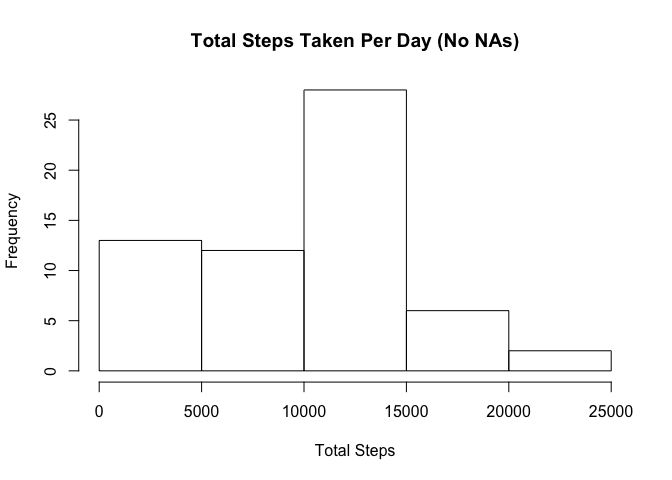

```r
numericStepsPerDay <- aggregate(numericActivityData$steps ~
                                    numericActivityData$date,
                                numericActivityData,
                                sum)
hist(numericStepsPerDay[ , 2],
     main = "Total Steps Taken Per Day (No NAs)",
     xlab = "Total Steps")
```

Comparing this histogram to the one generated previously, it is apparent that ignoring the NAs rather than replacing them with numeric values did have an effect on the results. The following is the mean for the data set with all numeric values.

```r
mean(numericStepsPerDay[ , 2])
```

```
## [1] 9354
```

And the following code calculates the median for this new data set.

```r
median(numericStepsPerDay[ , 2])
```

```
## [1] 10395
```

The difference between the original data set and this data set with all numeric values can be quantified by taking the difference between the means.

```r
abs(mean(numericStepsPerDay[ , 2]) - mean(stepsPerDay[ , 2]))
```

```
## [1] 1412
```

And between the medians.

```r
abs(median(numericStepsPerDay[ , 2]) - median(stepsPerDay[ , 2]))
```

```
## [1] 370
```

This result should make it obvious that ignoring NA values does affect the results of calculations made using those values. It should also be apparent that the strategy used to replace the NA values will impact the results, so it should be chosen with care.